# spark_project

```python
pandas_df = week_summary.toPandas() # convert to a pandas dataframe for use in plotting
```

Having successfully completed the data preparation and manipulation, we now convert our dataframe into a pandas dataframe, before plotting it with matplotlib

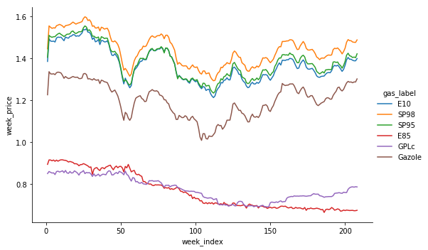

```python
import seaborn as sns
import matplotlib.pyplot as plt
%matplotlib inline


grid = sns.FacetGrid(pandas_df,
                     hue = "gas_label",
                     height = 5,
                     aspect = 1.5
                    )
grid.map(sns.lineplot, "week_index", "week_price")
grid.add_legend()
plt.show()
```

To display this information as a heatmap, we must retrieve the gas name and the average daily price index of each gas type over all stations from our main all_data_ddf. Before, we plotted the average PRICE over the week index, however this time we will plot the average PRICE INDEX over the week.

```python
heatmap_data = (all_ddf
                .groupBy(['gas_label','week_index'])
                .agg(F.mean('price_index').alias('av_gas_price'))
                .dropna()
               )


# An alternative way to perform the same command:
# heatmap_data = (sql_sc.sql("SELECT gas_label, day, AVG(price_index) AS av_gas_price '
#                            'FROM all_data GROUP BY gas_name, day"))

heatmap_data.show(5)
```

```
+---------+----------+------------------+
|gas_label|week_index|      av_gas_price|
+---------+----------+------------------+
|      E10|        38|100.00000000000004|
|     SP98|        78|100.00000000000003|
|      E10|       202|100.00000000000004|
|     SP95|        51|100.00000000000006|
|     SP98|        85|100.00000000000001|
+---------+----------+------------------+
only showing top 5 rows
```

```python
pdheatmap = heatmap_data.toPandas() # convert this information to Pandas dataframe for plotting
```

To be readable to the Seaborn heatmap function, the data must be in the form of a pivot table.

```python
result = pdheatmap.pivot(index = 'week_index', columns = 'gas_label', values = 'av_gas_price')
```

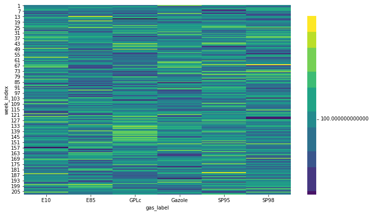

```python
plt.subplots(figsize=(12,7))
htmp = sns.heatmap(result,
                   fmt = "g",
                   cmap = 'viridis'
                  )
```

Having completed ths visualisation and manipulation part, we will now move onto modelling. Due to our estimating a continuous variable, I have chosen to implement a linear regression, using the pyspark library for machine learning. First, I add columns with 1-4 lags of the price to my dataframe. Then I create a pipeline which will carry out the column manipulations so the data is in the correct format, and the regression function itself.To build my model, I chose gas type 1, corresponding to Gazole, and station ID: 28190001.

```python
from pyspark.sql.window import Window
import pyspark.sql.functions as func

# average daily price has been stored in the price index, so we drop any multiple daily entries
model_data = (all_ddf
              .filter(F.col('station_id').isin(['28190001']))
              .filter(F.col('gas_type').isin(['1']))
              .dropDuplicates(['station_id', 'gas_label', 'year', 'week_index', 'day'])
              .drop('station_id','post_code','latitude','longitude','average_price_france',
                    'address','services','city','price_index', 'pop', 'gas_label','week',
                    'gas_type', 'station_type','year','month','price_date', 'average_price_station')
              .na.drop()
              )

model_data.show(5)
```

```
+---+-----+----------+
|day|price|week_index|
+---+-----+----------+
|302|1.215|        44|
|159|1.185|        76|
| 28|0.969|       108|
|333|1.135|       152|
| 15|0.989|       106|
+---+-----+----------+
only showing top 5 rows
```

```python
model_data.cache() # cache the data to save computing time
```

```
DataFrame[day: int, price: double, week_index: int]
```

```python
my_window = Window.partitionBy().orderBy("week_index","day")
```

```python
useful_lag = (
    model_data
    .withColumn('price_lag1',
                func.lag(model_data['price'],1).over(my_window))
    .withColumn('price_lag2',
                func.lag(model_data['price'],2).over(my_window))
    .withColumn('price_lag3',
                func.lag(model_data['price'],3).over(my_window))
    .withColumn('price_lag4',
                func.lag(model_data['price'],4).over(my_window))
    .na.drop(
        subset = ["price_lag1", "price_lag2", "price_lag3", "price_lag4"])
)
useful_lag.printSchema()
```

```
root
 |-- day: integer (nullable = true)
 |-- price: double (nullable = true)
 |-- week_index: integer (nullable = true)
 |-- price_lag1: double (nullable = true)
 |-- price_lag2: double (nullable = true)
 |-- price_lag3: double (nullable = true)
 |-- price_lag4: double (nullable = true)
```

```python
useful_lag.show(5) # let's see if the figures seem correct
```

```
+---+-----+----------+----------+----------+----------+----------+
|day|price|week_index|price_lag1|price_lag2|price_lag3|price_lag4|
+---+-----+----------+----------+----------+----------+----------+
| 66|1.309|        10|     1.325|     1.319|     1.315|     1.309|
| 74|1.299|        11|     1.309|     1.325|     1.319|     1.315|
| 80|1.289|        12|     1.299|     1.309|     1.325|     1.319|
| 90|1.295|        14|     1.289|     1.299|     1.309|     1.325|
|101|1.289|        15|     1.295|     1.289|     1.299|     1.309|
+---+-----+----------+----------+----------+----------+----------+
only showing top 5 rows
```

```python
from pyspark.ml.regression import LinearRegression
from pyspark.ml.feature import VectorAssembler
from pyspark.ml.feature import VectorIndexer
from pyspark.ml import Pipeline
from pyspark.ml.evaluation import RegressionEvaluator

# set the parameters of my linear regression
lr = LinearRegression(maxIter = 10,
                      labelCol = "price")

# creating features column
assembler = VectorAssembler(
    inputCols = ["price_lag1","price_lag2","price_lag3","price_lag4"],
    outputCol = "features")
```

Here, we define our test and training set, and create our pipeline including the steps we have defined above. This will enable us to quickly and easily (not including model fitting time) fit our model to our test data when we want to. I chose a 75%, 25% training, testing split.

```python
train, test = useful_lag.randomSplit([0.75, 0.25], seed=12345)
```

```python
pipeline = Pipeline(stages = [assembler, lr])
```

```python
# Fit the model
lrModel = pipeline.fit(train)
```

```python
# Print the coefficients and intercept for linear regression
print("Coefficients: %s" % str(lrModel.stages[-1].coefficients))
print("Intercept: %s" % str(lrModel.stages[-1].intercept))

# Summarize the model over the training data and print out some metrics
trainingSummary = lrModel.stages[-1].summary
print("numIterations: %d" % trainingSummary.totalIterations)
print("objectiveHistory: %s" % str(trainingSummary.objectiveHistory))

print("RMSE: %f" % trainingSummary.rootMeanSquaredError) # RMSE
print("r2: %f" % trainingSummary.r2) # R squared
```

```
Coefficients: [0.8281002400949498,-0.013440690427718711,0.25399551792959174,-0.11405890110282196]
Intercept: 0.05087055153647701
numIterations: 1
objectiveHistory: [0.0]
RMSE: 0.021579
r2: 0.933056
```

```python
train.describe().show() # get some general info
```

```
+-------+------------------+-------------------+------------------+-------------------+-------------------+-------------------+-------------------+
|summary|               day|              price|        week_index|         price_lag1|         price_lag2|         price_lag3|         price_lag4|
+-------+------------------+-------------------+------------------+-------------------+-------------------+-------------------+-------------------+
|  count|               217|                217|               217|                217|                217|                217|                217|
|   mean| 183.0552995391705| 1.1319631336405538|115.46082949308756| 1.1324331797235034|  1.131216589861752| 1.1327557603686642|    1.1326267281106|
| stddev|105.70274831752225|0.08359568993267545| 51.28117466707136|0.08482228920431864|0.08458019480429183|0.08419779554439014|0.08471714278881659|
|    min|                 2|              0.951|                10|              0.951|              0.951|              0.951|              0.951|
|    max|               366|              1.315|               206|              1.325|              1.319|              1.325|              1.319|
+-------+------------------+-------------------+------------------+-------------------+-------------------+-------------------+-------------------+
```

```python
lr_predictions = lrModel.transform(test) # predict values for the test set
```

```python
lr_evaluator = RegressionEvaluator(predictionCol = "prediction", labelCol = "price", metricName = "r2")
lr_evaluator.evaluate(predictions)
print("R Squared (R2) on test data = %g" % lr_evaluator.evaluate(lr_predictions)) # test data R squared value
```

```
R Squared (R2) on test data = 0.853292
```

With an R squared value of 0.853292, we are satisfied that 85% of the variation in the data is explained by the model.

```python
lr_predictions.show() # visualise our dataframe to see what we need ot keep for our dispersion plot
```

```
+---+-----+----------+----------+----------+----------+----------+--------------------+------------------+
|day|price|week_index|price_lag1|price_lag2|price_lag3|price_lag4|            features|        prediction|
+---+-----+----------+----------+----------+----------+----------+--------------------+------------------+
|  3|1.225|       157|     0.985|     1.225|     1.199|     1.179|[0.985,1.225,1.19...|1.0201496238534005|
|  8|1.085|        54|     1.095|     1.089|     1.075|     1.119|[1.095,1.089,1.07...|1.0884166740049146|
|  8|1.239|       157|     1.235|     1.225|     0.985|     1.225|[1.235,1.225,0.98...|1.1675729335894753|
| 16|1.069|        55|     1.076|     1.079|     1.085|     1.095|[1.076,1.079,1.08...|1.0780945451531514|
| 21|1.235|       159|     1.239|     1.235|     1.225|     0.985|[1.239,1.235,1.22...|1.2590839882133575|
| 22|0.979|       107|     0.989|     0.989|     0.969|     0.999|[0.989,0.989,0.96...|0.9887456608294236|
| 49|1.159|        60|     1.145|     1.129|     1.119|     1.109|[1.145,1.129,1.11...|1.1416004501924835|
| 59|1.179|        61|     1.169|     1.165|     1.159|     1.145|[1.169,1.165,1.15...|1.1670446913768466|
| 62|1.185|        62|     1.179|     1.169|     1.165|     1.159|[1.179,1.169,1.16...|1.1751990795082234|
| 73|1.215|       167|     1.227|     1.233|     1.229|     1.235|[1.227,1.233,1.22...|1.2216749235090862|
| 74|1.299|        11|     1.309|     1.325|     1.319|     1.315|[1.309,1.325,1.31...|1.3020774842029592|
| 78|1.195|       167|     1.199|     1.215|     1.227|     1.233|[1.199,1.215,1.22...| 1.198450175980473|
| 90|1.295|        14|     1.289|     1.299|     1.309|     1.325|[1.289,1.299,1.30...| 1.282184393161857|
| 97|1.199|       170|     1.189|     1.185|     1.191|     1.195|[1.189,1.185,1.19...| 1.185762793888797|
| 99|0.999|       118|     1.032|     1.032|     1.039|     1.012|[1.032,1.032,1.03...|1.0400729420058492|
|101|1.289|        15|     1.295|     1.289|     1.299|     1.309|[1.295,1.289,1.29...| 1.286572388745053|
|104|1.192|       171|     1.219|     1.209|     1.199|     1.189|[1.219,1.209,1.19...|1.2129995420714341|
|106|1.219|       171|     1.192|     1.219|     1.209|     1.199|[1.192,1.219,1.20...|1.1919057948528609|
|107|1.179|        68|     1.169|     1.149|     1.119|      1.16|[1.169,1.149,1.11...|1.1553890381899643|
|112|1.299|        17|     1.289|     1.259|     1.289|     1.295|[1.289,1.259,1.28...|1.2810638774534586|
+---+-----+----------+----------+----------+----------+----------+--------------------+------------------+
only showing top 20 rows
```

```python
disp_data = (lr_predictions
             .select("price", "prediction")
            )
disp_data.show()
```

```
+-----+------------------+
|price|        prediction|
+-----+------------------+
|1.225|1.0201496238534005|
|1.085|1.0884166740049146|
|1.239|1.1675729335894753|
|1.069|1.0780945451531514|
|1.235|1.2590839882133575|
|0.979|0.9887456608294236|
|1.159|1.1416004501924835|
|1.179|1.1670446913768466|
|1.185|1.1751990795082234|
|1.215|1.2216749235090862|
|1.299|1.3020774842029592|
|1.195| 1.198450175980473|
|1.295| 1.282184393161857|
|1.199| 1.185762793888797|
|0.999|1.0400729420058492|
|1.289| 1.286572388745053|
|1.192|1.2129995420714341|
|1.219|1.1919057948528609|
|1.179|1.1553890381899643|
|1.299|1.2810638774534586|
+-----+------------------+
only showing top 20 rows
```

```python
disp_plot_df = disp_data.toPandas()
```

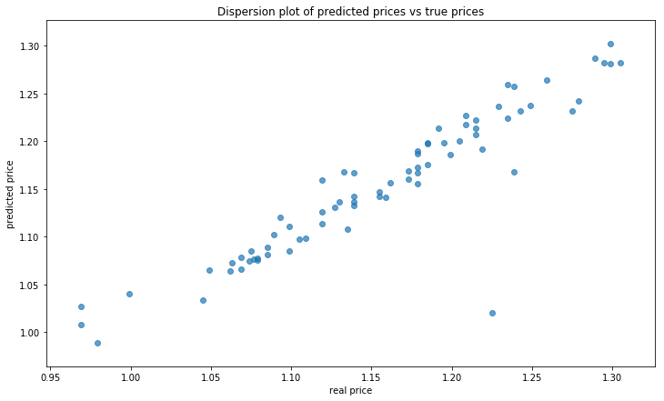

```python
plt.figure(figsize=(12,7))
plt.scatter(disp_plot_df['price'], disp_plot_df['prediction'], alpha=0.7)
plt.title("Dispersion plot of predicted prices vs true prices")
plt.xlabel("real price")
plt.ylabel("predicted price")
plt.show()
```

```python
sc.stop() # ending our Spark session
```